# Practical Machine Learning Assignment

Ramesh Natarajan

Sunday, April 26, 2015

### Introduction

This assignment involves analysis of activity quality for a group of enthusiasts who take measurements about themselves regularly to improve their health. For this analysis, we have been provided data from accelerometers on the belt, forearm, arm, and dumbell of 6 participants who were asked to perform barbell lifts correctly and incorrectly in 5 different ways. The activity quality is provided by the “classe” variable in the training set.

The objective of this assignment is to fit a model on training data and apply the model to predict the “classe”" variable on a set of test data.

### Loading Data

```r
# Download training and testing files if they are not already downloaded

if (!file.exists("./pml-training.csv")) {
                 download.file("https://d396qusza40orc.cloudfront.net/predmachlearn/pml-training.csv", "./pml-training.csv")

}

if (!file.exists("./pml-testing.csv")) {
                 download.file("https://d396qusza40orc.cloudfront.net/predmachlearn/pml-testing.csv", "./pml-testing.csv")

}
# Read training and test set rationalizing missing values

training <- read.table("./pml-training.csv", header=TRUE, sep = ",", na.strings = c("NA", "#DIV/0!", ""))

testing <- read.table("./pml-testing.csv", header=TRUE, sep = ",", na.strings = c("NA", "#DIV/0!", ""))
```

### Cleaning Data for relevant feature selection

We will clean the training data and extract only columns that have meaningful data for our model fitting

```r
# remove all columns from analysis that have more than 50% missing values or that are not relevant for the analysis (columns 1 to 7)

badcols <- NULL

dlen <- length(training)
for (Var in names(training)) {
    missing <- sum(is.na(training[,Var]))
    if (missing > dlen/2) {
      badcols <- c(badcols, Var)
    }
}
trnClean <- training[, !(names(training) %in% badcols)]
trnClean <- trnClean[, -c(1:7)]
```

### Model fitting, accuracy check and cross validation

In the next section, we will split the data into training and testing set and fit a model using random forest due to its high accuracy.

```r
library(caret)
library(randomForest)
```

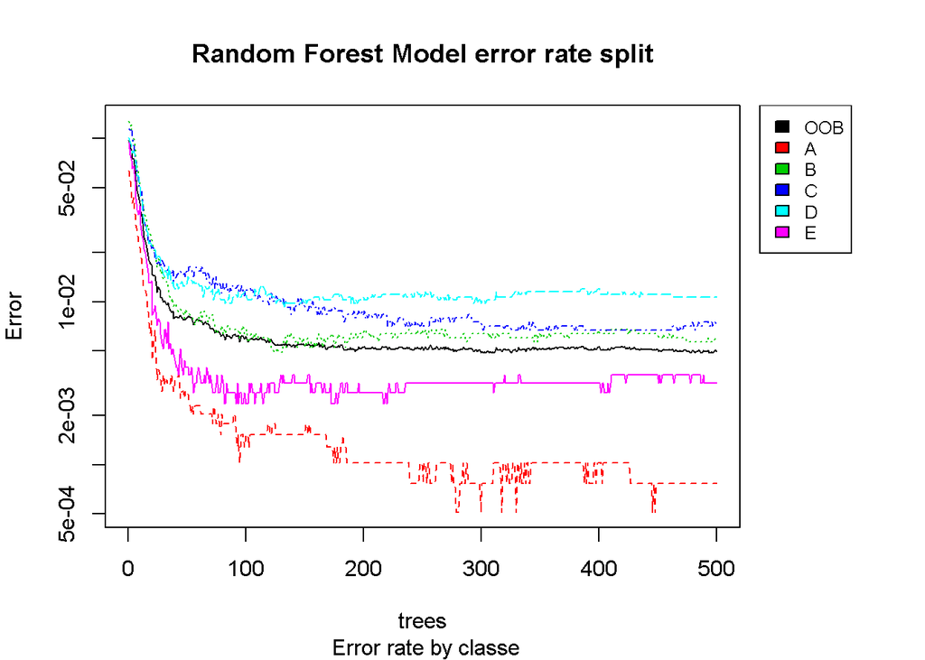

```r
# Split data into training and testing set

inTrain <- createDataPartition(y=trnClean$classe, p=0.7, list = FALSE)

trainingSet <- trnClean[inTrain, ]
testingSet <- trnClean[-inTrain, ]

# Fit a model using random forest

set.seed(3873)
modFitRF <- randomForest(classe ~. , proximity = TRUE, data=trainingSet, importance = TRUE)

layout(matrix(c(1,2),nrow=1),width=c(4,1))
par(mar=c(5,4,4,0)) #No margin on the right side
plot(modFitRF, log="y", main = "Random Forest Model error rate split", sub = " Error rate by classe")
par(mar=c(5,0,4,2)) #No margin on the left side
plot(c(0,1),type="n", axes=F, xlab="", ylab="")
legend("top", colnames(modFitRF$err.rate),col=1:6,cex=0.8,fill=1:6)
```

```r
print(modFitRF)
```

```
##
## Call:
##  randomForest(formula = classe ~ ., data = trainingSet, proximity = TRUE,      importance = TRUE)
##                Type of random forest: classification
##                      Number of trees: 500
## No. of variables tried at each split: 7
##
##         OOB estimate of  error rate: 0.5%
## Confusion matrix:
##      A    B    C    D    E  class.error
## A 3903    2    0    0    1 0.0007680492
## B   13 2642    3    0    0 0.0060195636
## C    0   16 2379    1    0 0.0070951586
## D    0    0   22 2228    2 0.0106571936
## E    0    0    2    6 2517 0.0031683168
```

```r
pred <- predict(modFitRF, testingSet, type = "class")

confusionMatrix(pred, testingSet$classe)
```

```
## Confusion Matrix and Statistics
##
##           Reference
## Prediction    A    B    C    D    E
##          A 1674    5    0    0    0
##          B    0 1133    8    0    0
##          C    0    1 1018   17    0
##          D    0    0    0  946    1
##          E    0    0    0    1 1081
##
## Overall Statistics
##
##                Accuracy : 0.9944
##                  95% CI : (0.9921, 0.9961)
##     No Information Rate : 0.2845
##     P-Value [Acc > NIR] : < 2.2e-16
##
##                   Kappa : 0.9929
##  Mcnemar's Test P-Value : NA
##
## Statistics by Class:
##
##                      Class: A Class: B Class: C Class: D Class: E
## Sensitivity            1.0000   0.9947   0.9922   0.9813   0.9991
## Specificity            0.9988   0.9983   0.9963   0.9998   0.9998
## Pos Pred Value         0.9970   0.9930   0.9826   0.9989   0.9991
## Neg Pred Value         1.0000   0.9987   0.9984   0.9964   0.9998
## Prevalence             0.2845   0.1935   0.1743   0.1638   0.1839
## Detection Rate         0.2845   0.1925   0.1730   0.1607   0.1837
## Detection Prevalence   0.2853   0.1939   0.1760   0.1609   0.1839
## Balanced Accuracy      0.9994   0.9965   0.9942   0.9906   0.9994
```

An accuracy of .99 on out of sample data shows that the model provides a high degree of accuracy for the estimate.

Having cross validated the model, we can now proceed to predict the “classe” variable (activity quality) for the test data provided for this assignment.

```r
answers <- predict(modFitRF, testing, type="class")

## function for writing files with prediction for each row of data
pml_write_files = function(x){
  n = length(x)
  for(i in 1:n){
    filename = paste0("problem_id_",i,".txt")
    write.table(x[i],file=filename,quote=FALSE,row.names=FALSE,col.names=FALSE)
  }
}

## write 20 files with prediction values for each test row to current directory

pml_write_files(answers)
```